# EDA WHO Lab

In the Data Wrangling document we managed to structure a data table into a tidy dataset. Below you can see the result:

```r
new_who = who %>%
  pivot_longer(cols = new_sp_m014:newrel_f65, names_to = "key", values_to = "cases") %>%
  drop_na() %>%
  mutate(key = str_replace(key, "newrel", "new_rel")) %>%
  tidyr::separate(col = key, into = c("new", "type", "sexage"), sep = "_") %>%
  select(-c(iso2, iso3, new)) %>%
  tidyr::separate(col = sexage, into = c("sex", "age"), sep = 1)
new_who
```

| country | year | type | sex | age | cases |
| --- | --- | --- | --- | --- | --- |
| Afghanistan | 1997 | sp | m | 014 | 0 |
| Afghanistan | 1997 | sp | m | 1524 | 10 |
| Afghanistan | 1997 | sp | m | 2534 | 6 |
| Afghanistan | 1997 | sp | m | 3544 | 3 |
| Afghanistan | 1997 | sp | m | 4554 | 5 |
| Afghanistan | 1997 | sp | m | 5564 | 2 |
| Afghanistan | 1997 | sp | m | 65 | 0 |
| Afghanistan | 1997 | sp | f | 014 | 5 |
| Afghanistan | 1997 | sp | f | 1524 | 38 |
| Afghanistan | 1997 | sp | f | 2534 | 36 |

[output cut: 990 more lines]

new_who` is now a dataset on which we can start working to clean it up and study the variation and covariation of its components.

First we must understand the different variables that we will find. To do this you can search for `who` in the R studio help menu.

You may remember that in the previous process we removed all the missing values to organize the structure of our data table. Now that we know how to analyze the missing values we are going to recreate the dataset without removing these values:

```r
# recreate the dataset without removing the NA's
new_who = who %>%
  pivot_longer(cols = new_sp_m014:newrel_f65, names_to = "key", values_to = "cases") %>%
  mutate(key = str_replace(key, "newrel", "new_rel")) %>%
  tidyr::separate(col = key, into = c("new", "type", "sexage"), sep = "_") %>%
  select(-c(iso2, iso3, new)) %>%
  tidyr::separate(col = sexage, into = c("sex", "age"), sep = 1)
new_who
```

| country | year | type | sex | age | cases |
| --- | --- | --- | --- | --- | --- |
| Afghanistan | 1980 | sp | m | 014 | NA |
| Afghanistan | 1980 | sp | m | 1524 | NA |
| Afghanistan | 1980 | sp | m | 2534 | NA |
| Afghanistan | 1980 | sp | m | 3544 | NA |
| Afghanistan | 1980 | sp | m | 4554 | NA |
| Afghanistan | 1980 | sp | m | 5564 | NA |
| Afghanistan | 1980 | sp | m | 65 | NA |
| Afghanistan | 1980 | sp | f | 014 | NA |
| Afghanistan | 1980 | sp | f | 1524 | NA |
| Afghanistan | 1980 | sp | f | 2534 | NA |

[output cut: 990 more lines]

Initially we may think that the missing values are due to problems in data collection. This, in principle, may be influenced by the year in which they were collected, by the country in which the data is being collected, or by the type of tuberculosis. Let us analyze this with R. Count the number of missing values per year, per country and per type of tuberculosis:

```r
# Count the number of missing values per year
new_who %>%
  group_by(year) %>%
  summarise(na_count = sum(is.na(cases))) %>%
  arrange(na_count)
```

| year | na_count |
| --- | --- |
| 2012 | 4764 |
| 2011 | 4812 |
| 2010 | 4927 |
| 2009 | 5480 |
| 2008 | 5509 |
| 2007 | 5724 |
| 2006 | 5880 |
| 2003 | 9211 |
| 2004 | 9226 |
| 2005 | 9354 |

[output cut: 24 more lines]

```r
# Count the number of missing values per country
new_who %>%
  group_by(country) %>%
  summarise(na_count = sum(is.na(cases))) %>%
  arrange(na_count)
```

| country | na_count |
| --- | --- |
| Bonaire, Saint Eustatius and Saba | 84 |
| Curacao | 84 |
| South Sudan | 126 |
| Sint Maarten (Dutch part) | 148 |
| Serbia | 182 |
| Montenegro | 186 |
| Timor-Leste | 522 |
| Canada | 1232 |
| Switzerland | 1246 |
| Israel | 1260 |

[output cut: 209 more lines]

```r
# Count the number of missing values per type
new_who %>%
  group_by(type) %>%
  summarise(na_count = sum(is.na(cases))) %>%
  arrange(na_count)
```

| type | na_count |
| --- | --- |
| sp | 56540 |
| sn | 87018 |
| ep | 87056 |
| rel | 98780 |

**Question 1:** Do you think those variables have an effect in the missing data? Explain which strategy should we use to handle the missing data in this dataset.

For now, we will use the initial strategy of eliminating the cases in the previous data wrangling phase to make the lab easier. In addition to this step we will convert all the character variables into factors to be used later in the analysis:

```r
# drop all the NA's while creating the dataset and transform the chr variables into fct
new_who = who %>%
  pivot_longer(cols = new_sp_m014:newrel_f65, names_to = "key", values_to = "cases") %>%
  drop_na() %>%
  mutate(key = str_replace(key, "newrel", "new_rel")) %>%
  tidyr::separate(col = key, into = c("new", "type", "sexage"), sep = "_") %>%
  select(-c(iso2, iso3, new)) %>%
  tidyr::separate(col = sexage, into = c("sex", "age"), sep = 1) %>%
  mutate(country = factor(country),
         type = factor(type),
         sex = factor(sex),
         age = factor(age))
new_who
```

| country | year | type | sex | age | cases |
| --- | --- | --- | --- | --- | --- |
| Afghanistan | 1997 | sp | m | 014 | 0 |
| Afghanistan | 1997 | sp | m | 1524 | 10 |
| Afghanistan | 1997 | sp | m | 2534 | 6 |
| Afghanistan | 1997 | sp | m | 3544 | 3 |
| Afghanistan | 1997 | sp | m | 4554 | 5 |
| Afghanistan | 1997 | sp | m | 5564 | 2 |
| Afghanistan | 1997 | sp | m | 65 | 0 |
| Afghanistan | 1997 | sp | f | 014 | 5 |
| Afghanistan | 1997 | sp | f | 1524 | 38 |
| Afghanistan | 1997 | sp | f | 2534 | 36 |

[output cut: 990 more lines]

It may be a good strategy to start studying the variation of the dataset to try to detect patterns or strange cases. Let’s start by looking at the distribution of our single numeric variable, `cases`:

```r
# Create a plot to see the distribution of the continuous variable
```

[output not shown]

**Question 2:** Is this variable normally distributed? Explain how can we visualize the outliers of this variable and obtain that plot using R.

```r
# Use the best plot to visualize the outliers
```

[output not shown]

In this case there are too many extreme values, so we will not eliminate them. We will work with a transformation of this variable to collect as much information as possible.

It seems clear that the number of extreme values is not manageable by an elimination strategy. In these cases it is most appropriate to use a logarithmic transformation of the variable to work with it in subsequent analyses. Let us see how the transformed variable is distributed with a logarithm of base e:

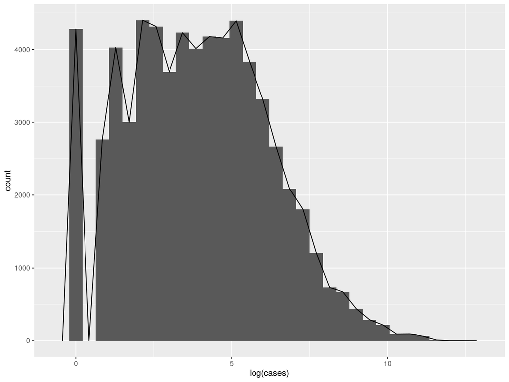

```r
# Create a histogram with the log transformed variable
ggplot(new_who) +
  geom_histogram(aes(log(cases))) +
  geom_freqpoly(aes(log(cases)))
```

```r
# Count how many values we have in cases equal to 0
```

```r
# create a new variable called "scaled_cases" adding 1 to each observation
```

```r
# create a histogram with the logarithm of the scaled variable
```

[output not shown]

**Question 3:** Interpret the plot after the transformation. Can we assume normality now?